# Curation of motifs from ESC model

Khayti Dalal

January 27, 2024

# Introduction

The goal of this analysis is to curate motifs found by the `ESC model` TF-MoDISco run such that there are no redundancies due palindromes, sequence similarity, overlapping peak regions etc.

# Computational Setup

```r
#Standard packages
library(rtracklayer) ; library(GenomicRanges); library(magrittr) ; library(Biostrings)
library(ggplot2) ; library(reshape2); library(plyranges); library(Rsamtools);library(BSgenome.Mmusculus.UCSC.mm10)
library(dplyr); library(data.table); library(patchwork); library(readr); library(testit);library(TxDb.Mmusculus.UCSC.mm10.knownGene)

#KNITR Options
setwd("/n/projects/kd2200/publication/bpnet/analysis/")
options(knitr.figure_dir="figures/1_motif_curation/", java.parameters = "- Xmx6g")

#Lab sources
source("/n/projects/kd2200/publication/bpnet/analysis/scripts/granges_common.r")
source("/n/projects/kd2200/publication/bpnet/analysis/scripts/metapeak_common.r")
source("/n/projects/kd2200/publication/bpnet/analysis/scripts/knitr_common.r")
source("/n/projects/kd2200/publication/bpnet/analysis/scripts/caching.r")
source("/n/projects/kd2200/publication/bpnet/analysis/scripts/metapeak_functions.R")
source("/n/projects/kd2200/publication/bpnet/analysis/scripts/multiplot.R")
source("/n/projects/kd2200/publication/bpnet/analysis/scripts/motif_functions.R")


#Pre-existing variables
#fold1
#modisco_dir <- '/n/projects/kd2200/publication/bpnet/bpnet_single_tead4_esc/tead4_esc/modisco/profile/dataspec.yaml_default/'

#fold2
#modisco_dir <- '/n/projects/kd2200/publication/bpnet/bpnet_single_tead4_esc/tead4_esc/modisco/profile/dataspec.yaml_default_fold_2/'

#fold5
modisco_dir <- '/n/projects/kd2200/publication/bpnet/bpnet_single_tead4_esc/tead4_esc/modisco/profile/dataspec.yaml_default_fold_5/'

tasks <- c('tead4_esc')
threads <- 2
```

# Summary of motifs of interest

Based on the TF-MoDISco model, the following motifs are of interest to us:

```r
# motif set of interest.
motifs_of_interest.df <- data.frame(
  name = c('tead4_1','tead4_double_2'),
  task = c('tead4_esc','tead4_esc'),
  pattern = c(1,2)
)
motifs_of_interest.df
```

```
##             name      task pattern
## 1        tead4_1 tead4_esc       1
## 2 tead4_double_2 tead4_esc       2
```

```r
#fold2&5
motifs_of_interest.df <- data.frame(
  name = c('tead4_0','tead4_double_1'),
  task = c('tead4_esc','tead4_esc'),
  pattern = c(0,1)
)
motifs_of_interest.df
```

```
##             name      task pattern
## 1        tead4_0 tead4_esc       0
## 2 tead4_double_1 tead4_esc       1
```

# Collect motif instances

First, extract each mapped set of instances from each pattern to allocate the non-curated set of motifs of interest.

```r
cmds.vec<-lapply(1:nrow(motifs_of_interest.df), function(x){
  info.df<-motifs_of_interest.df[x,]
  cmd<-paste0('bpnet cwm-scan --patterns metacluster_0/pattern_', info.df$pattern, ' ',' ',
         modisco_dir, '/', info.df$task,' ',' ', '/n/projects/kd2200/publication/bpnet/bpnet_single_tead4_esc/tsv/fold5/',
         info.df$name, '_instances-all-regions.tsv.gz')
  return(cmd)
}) %>% unlist
cmds.vec<-c('#!bin/bash', cmds.vec, '')


readr::write_lines(cmds.vec, file = '/n/projects/kd2200/publication/bpnet/analysis/tmp/esc_model_cwm_scan_indiv_instances_fold5.sh', sep = '\n')
```

Run CWM-scanning to allocate.

```bash
conda activate bpnet
<!-- bash /n/projects/kd2200/publication/bpnet/analysis/tmp/esc_model_cwm_scan_indiv_instances.sh -->
```

Next import motifs.

```r
motifs.df<-lapply(1:nrow(motifs_of_interest.df), function(x){
    info.df<-motifs_of_interest.df[x,]
    df<-readr::read_tsv(paste0('/n/projects/kd2200/publication/bpnet/bpnet_single_tead4_esc/tsv/fold5/', info.df$name, '_instances-all-regions.tsv.gz')) %>%
        dplyr::mutate(pattern_name = info.df$name,
                      modisco_task = info.df$task)
}) %>% rbindlist(fill = TRUE)
```

Report number of motifs

```r
motifs.df$pattern_name %>% table
```

```
## .
##        tead4_0 tead4_double_1
##          15736           1400
```

# Remove redundant palindromic mappings

Motifs that are palindromic will be mapped on the positive and negative strand with almost identical ranges. Here, we will remove redundantly mapped motifs and select the unique motif maps that have the highest importance score.

```r
#Remove palindromic motifs for each pattern.
motifs.gr<-lapply(motifs.df$pattern_name %>% unique, function(x){
  message(x)
  gr<-remove_palindromic_motifs_from_bpnet_instances(dfi = motifs.df, x)
}) %>% GRangesList %>% unlist
```

# Measure %age of motifs across enhancer edges

```r
edge_motifs.vec<-motifs.gr %>% plyranges::filter(pattern_center <=100 | pattern_center>=900) %>% .$pattern_name %>% table
total_motifs.vec<-motifs.gr$pattern_name %>% table
round(edge_motifs.vec/total_motifs.vec, 2)
```

```
## .
##        tead4_0 tead4_double_1
##           0.01           0.01
```

Less than 5% of all motifs are on mapped BPNet window edges.

Consolidate motifs.

```r
motifs_curated.gr<- motifs.gr %>% plyranges::arrange(pattern_name)
motifs_curated.gr$motif_type<-"short"
motifs_curated.gr<-motifs_curated.gr %>% plyranges::mutate(motif_id = 1:length(.))
```

Plot a general summary of the motifs.

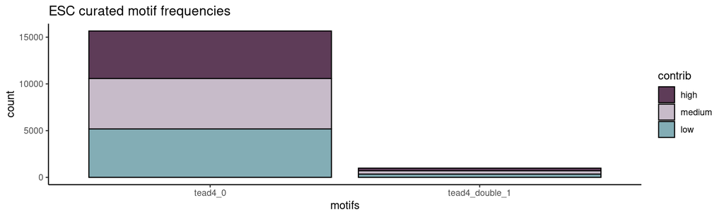

```r
ggplot(motifs.gr %>% as.data.frame, aes(x = pattern_name))+
    geom_bar(aes(fill = factor(contrib_weighted_cat, levels = c('high','medium','low'))), color = 'black')+
    scale_fill_manual(values = rev(c('#83adb5', '#c7bbc9', '#5e3c58')), name = 'contrib')+
    scale_x_discrete(name = 'motifs')+
    ggtitle('ESC curated motif frequencies')+
    theme_classic()
```

## Double check motif overlaps

Ensure that there isn’t an overrepresentation of unexpected overlapping motif pairs. We expect some overlaps, but checking to make sure that our curations are consistent. Here, we will filter out the longer motifs because we know that those overlaps will be highly represented.

```r
short_motifs.gr<-motifs_curated.gr %>% plyranges::filter(motif_type=='short')
overlapping_motifs.gr<- short_motifs.gr %>%
  GenomicRanges::reduce(ignore.strand = T) %>%
  plyranges::mutate(motif_island_id = 1:length(.))
overlapping_motifs.ov<-findOverlaps(short_motifs.gr, overlapping_motifs.gr, ignore.strand = T)
assert('IDs do not allow indexing shortcut.', 1:length(short_motifs.gr)==overlapping_motifs.ov@from)
short_motifs.gr$motif_island_id<-overlapping_motifs.ov@to

#Group motifs by their island ID and display frequency of motif contents
grouped_motif_content.df<-short_motifs.gr %>% as.data.frame %>%
  dplyr::group_by(motif_island_id) %>%
  dplyr::summarize(motif_content = paste0(sort(pattern_name), collapse = '_'))

grouped_motif_content.df$motif_content %>% table() %>% sort(decreasing = T) %>% .[1:5]
```

```
## .
##                        tead4_0         tead4_0_tead4_double_1
##                          15018                            530
##                 tead4_double_1                tead4_0_tead4_0
##                            441                             43
## tead4_0_tead4_0_tead4_double_1
##                             12
```

# Annotate motifs by their collected regional grouping

Because we took motifs based on their relative contribution and not the featured `example_idx` column, we need a new grouping annotation to define the motifs when we are conducting perturbations and other grouping systems. We will call this index `region_id`.

```r
islands.gr<-resize(motifs_curated.gr, 200, 'center') %>%
  GenomicRanges::reduce(ignore.strand = T) %>%
  plyranges::mutate(region_id = 0:(length(.)-1)) #Make region_id 0-based in order to be compatible with BPNet indexing properties.
ov<-findOverlaps(motifs_curated.gr, islands.gr, ignore.strand = T)
testit::assert(ov@from %>% unique %>% length == ov@from %>% length)

#Show hoy many motifs there are per window
ov@to %>% table %>% table
```

```
## .
##    1    2    3    4    5    6    7   15
## 8659 2794  620   91   24    6    1    1
```

```r
#Assign region_id to these motifs
motifs_curated.gr$region_id<-islands.gr$region_id[ov@to]
motifs_curated.gr$region_start_1based<-islands.gr[ov@to] %>% resize(., 1000, 'center') %>% start()
motifs_curated.gr$region_end_1based<-islands.gr[ov@to] %>% resize(., 1000, 'center') %>% end()

#Assert that all motifs are incorporated.
testit::assert('All motifs have a correct region', all(overlapsAny(motifs_curated.gr, resize(islands.gr, 1000, 'center'))))

#Export regions in 0-based coordinates
islands.gr<-islands.gr %>% resize(., 1000, 'center')
rtracklayer::export(islands.gr %>% plyranges::mutate(name = region_id), 'bed/curated_island_regoion_esc_model_motifs_fold5_0based.bed', format = 'BED') #curated_island_regoion_esc_model_motifs_fold1_0based.bed
```

# Export curated motifs

```r
motifs_curated.df<-motifs_curated.gr %>% as.data.frame()
readr::write_tsv(motifs_curated.df, 'tsv/curated_motif_regoion_esc_model_motifs_fold5_1based.tsv.gz')
rtracklayer::export(motifs_curated.gr %>% plyranges::mutate(name = paste0(pattern_name, '_', region_id)),
                    'bed/curated_motif_regoion_esc_model_motifs_fold5_0based.bed', format = 'BED')

mm10_promoters <-promoters(TxDb.Mmusculus.UCSC.mm10.knownGene,upstream=1000, downstream=200)
rm <- readRDS("/n/projects/kd2200/publication/bpnet/analysis/data/repeatmasker.mm10.gr.rds")
erv <- rm[grep("ERV", rm$repeat_class)]
gr_no_erv <- motifs_curated.gr[which(!overlapsAny(motifs_curated.gr, erv, ignore.strand=T))]
gr_no_erv_no_promo <- gr_no_erv[which(!overlapsAny(gr_no_erv, mm10_promoters, ignore.strand=T))]

##noerv_nopromo
motifs_curated2.df<-gr_no_erv_no_promo %>% as.data.frame()
readr::write_tsv(motifs_curated2.df, 'tsv/curated_motif_regoion_esc_model_motifs_fold5_1based_noerv_nopromoter.tsv.gz')
rtracklayer::export(gr_no_erv_no_promo %>% plyranges::mutate(name = paste0(pattern_name, '_', region_id)),
                    'bed/curated_motif_regoion_esc_model_motifs_fold5_0based_noerv_nopromoter.bed', format = 'BED')

##noerv
motifs_curated3.df<-gr_no_erv %>% as.data.frame()
readr::write_tsv(motifs_curated3.df, 'tsv/curated_motif_regoion_esc_model_motifs_fold5_1based_noerv.tsv.gz')
rtracklayer::export(gr_no_erv %>% plyranges::mutate(name = paste0(pattern_name, '_', region_id)),
                    'bed/curated_motif_regoion_esc_model_motifs_fold5_0based_noerv.bed', format = 'BED')
```

In conclusion, motifs were curated based on redundancies and saved to 1-based and 0-based coordinates. These will be the reference motifs that we base subsequent analysis on.